# Technologie NoSQL

## ZADANIE 1

Tabele zostały wykonane przy pomocy CsvToMarkdownTable z plików .csv. Każdy wynik agregacji został wyeksportowany do pliku .csv przy pomocy skryptów JS. Owe skrypty są opisane pod każdą agregacją.

1a) Zbiór został przedstawiony i zaimportowany do obu baz w zadaniu geo.

### PostgreSQL

1b) Liczba zaimportowanych obiektów:

```bash
 SELECT COUNT(*) FROM mydb.crime;
     count
   ---------
     1614639
```

Czas: 343 ms.

1c)

Wszystkie agregacje są wykonane przy pomocy JavaScript.

#### Agregacja 1

Najczęściej popełniane przestępstwa posortowane malejąco według ilości:

```sql
  SELECT crime_type, COUNT(*) AS count FROM mydb.crime GROUP BY crime_type ORDER BY count DESC
```

Czas wykonania: 680ms.

[Skrypt z agregacją](https://github.com/abie115/nosql/tree/master/zadanie1/scripts/pg_agg1.js) uruchamiamy w folderze ze skryptami:

```bash
cd zadanie1/scripts
node pg_agg1.js pg_agg1.csv
```

Wynik zapisany do [pliku csv](https://github.com/abie115/nosql/tree/master/zadanie1/results/pg_agg1.csv).

| crime_type | count |
| --- | --- |
| Anti-social behaviour | 607167 |
| Violence and sexual offences | 276976 |
| Criminal damage and arson | 162359 |
| Burglary | 116191 |
| Other theft | 110112 |
| Vehicle crime | 94465 |
| Shoplifting | 84759 |
| Public order | 58314 |
| Drugs | 32178 |
| Theft from the person | 19430 |
| Bicycle theft | 19189 |
| Other crime | 15874 |
| Robbery | 11578 |
| Possession of weapons | 6047 |

#### Agregacja 2

Porównanie przestępstw narkotykowych zgłoszonych przez Cumbria Constabulary w 2016 roku:

```sql
SELECT reported_by, TO_CHAR(month, 'YYYY-MM') AS date_month, COUNT(*) AS count FROM mydb.crime WHERE month > '2015-12-31'
  AND crime_type LIKE 'Drugs' AND reported_by LIKE 'Cumbria Constabulary' GROUP BY reported_by, month ORDER BY count DESC
```

Czas wykonania: 485ms.

[Skrypt z agregacją](https://github.com/abie115/nosql/tree/master/zadanie1/scripts/pg_agg2.js) uruchamiamy w folderze ze skryptami:

```bash
cd zadanie1/scripts
node pg_agg2.js pg_agg2.csv
```

Wynik zapisany do [pliku csv](https://github.com/abie115/nosql/tree/master/zadanie1/results/pg_agg2.csv).

Tworzę wykres porównawczy:

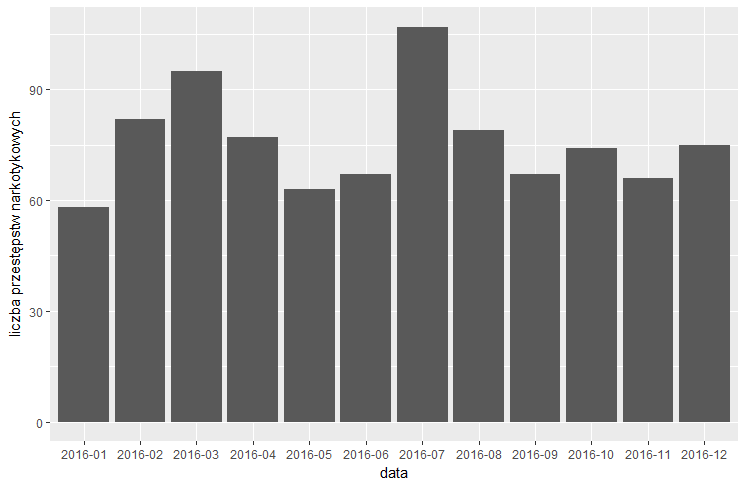

```r
require(ggplot2);
data<-read.csv(file = "D:\\z-nosql\\nosql\\zadanie1\\results\\pg_agg1.csv", header=TRUE)
ggplot( data = data, aes(date_month,count,group = 1 )) + geom_bar(stat="identity") +
      xlab("data") + ylab("liczba przestępstw narkotykowych")
```

#### Agregacja 3

5 najczęstszych stanów przestępstwa (last_outcome_category) kradzieży samochodu od czerwca 2015 do grudnia 2015:

```sql
SELECT last_outcome_category, COUNT(*) AS count FROM mydb.crime WHERE crime_type='Vehicle crime'
    AND month >='2015-06-01' AND month <='2015-12-31'
                GROUP BY last_outcome_category ORDER BY count DESC LIMIT 5
```

Czas wykonania: 433ms.

[Skrypt z agregacją](https://github.com/abie115/nosql/tree/master/zadanie1/scripts/pg_agg3.js) uruchamiamy w folderze ze skryptami:

```bash
cd zadanie1/scripts
node pg_agg2.js pg_agg2.csv
```

Wynik zapisany do [pliku csv](https://github.com/abie115/nosql/tree/master/zadanie1/results/pg_agg3.csv).

| last_outcome_category | count |
| --- | --- |
| Investigation complete; no suspect identified | 24505 |
| Under investigation | 1008 |
| Unable to prosecute suspect | 893 |
| Court result unavailable | 470 |
| Offender sent to prison | 186 |

#### Agregacja 4

3 miesiące o największej aktywności przestępstw w lokalizacji, w której jest największa liczba przestępstw:

```sql
  SELECT a.location, to_char(a.month,'YYYY-MM') AS date_month, COUNT(*) AS count
        FROM mydb.crime a
            WHERE EXISTS
                (SELECT b.location FROM
                    (SELECT c.location, COUNT(*) AS count FROM mydb.crime c GROUP BY c.location
                        ORDER BY count DESC LIMIT 1) b
                            WHERE a.location = ''||b.location||'' ) GROUP BY a.month, a.location
                            ORDER BY count DESC LIMIT 3;
```

Czas wykonania: 1439 ms.

[Skrypt z agregacją](https://github.com/abie115/nosql/tree/master/zadanie1/scripts/pg_agg4.js) uruchamiamy w folderze ze skryptami:

```bash
cd zadanie1/scripts
node pg_agg4.js pg_agg4.csv
```

Wynik zapisany do [pliku csv](https://github.com/abie115/nosql/tree/master/zadanie1/results/pg_agg4.csv).

| location | date_month | count |
| --- | --- | --- |
| On or near Parking Area | 2016-10 | 2347 |
| On or near Parking Area | 2016-08 | 2209 |
| On or near Parking Area | 2016-09 | 2200 |

#### Agregacja 5

Średnia liczba przestępstw w miesiącu:

```sql
SELECT ROUND(AVG(count)) AS result FROM (SELECT to_char(month,'YYYY-MM'), COUNT(*) AS count FROM mydb.crime GROUP BY month) a
```

Czas wykonania: 635ms.

Wynik: 67277.

[Skrypt z agregacją](https://github.com/abie115/nosql/tree/master/zadanie1/scripts/pg_agg5.js) uruchamiamy w folderze ze skryptami:

```bash
cd zadanie1/scripts
node pg_agg5.js
```

### ElasticSearch

1b) Liczba zaimportowanych obiektów:

```bash
curl -XGET "http://localhost:9200/db_crimes/_count"
{"count":1614639,"_shards":{"total":5,"successful":5,"failed":0}}
```

Czas: 383 ms.

Wszystkie agregacje są wykonane przy pomocy JavaScript.

1c) Dla porównania czasów wykonuje 3 pierwsze agregacje takie same jak w PostgreSQL.

Wykresy i tabelki pominęłam, ponieważ wyniki agregacji są takie same jak w PostgreSQL.

#### Agregacja 1

Najczęściej popełniane przestępstwa posortowane malejąco według ilości:

```bash
 {
        "size": 0,
        "aggs": {
            "group_by_crime": {
                "terms": {
                    "size": 50,
                    "field": "crime_type.keyword"
                }
            }
        }
    }
```

Czas wykonania: 45ms.

[Skrypt z agregacją](https://github.com/abie115/nosql/tree/master/zadanie1/scripts/es_agg1.js) uruchamiamy w folderze ze skryptami:

```bash
cd zadanie1/scripts
node es_agg1.js es_agg1.csv
```

Wynik zapisany do [pliku csv](https://github.com/abie115/nosql/tree/master/zadanie1/results/es_agg1.csv).

#### Agregacja 2

Porównanie przestępstw narkotykowych zgłoszonych przez Cumbria Constabulary w 2016 roku:

```bash
{
     "query": { "bool": { "filter": [
         {"term": {"reported_by.keyword": "Cumbria Constabulary" }},
         {"term": {"crime_type.keyword": "Drugs" }},
         {"range": {"month": {"from": "2015-12" } }}
            ]}},
    "size":0,
     "aggs": {
      "group_by_reported": {
       "terms": { "field" : "reported_by.keyword" },
       "aggs": {
        "group_by_month": {
         "terms": { "size": 50, "field": "month"}
       }
      }
     }
    }
}
```

Czas wykonania: 41ms.

[Skrypt z agregacją](https://github.com/abie115/nosql/tree/master/zadanie1/scripts/es_agg2.js) uruchamiamy w folderze ze skryptami:

```bash
cd zadanie1/scripts
node es_agg2.js es_agg2.csv
```

Wynik zapisany do [pliku csv](https://github.com/abie115/nosql/tree/master/zadanie1/results/es_agg2.csv).

#### Agregacja 3

5 najczęstszych stanów przestępstwa (last_outcome_category) kradzieży samochodu od czerwca 2015 do grudnia 2015:

```bash
{
    "query": {
     "bool": {
       "filter": [
         {"term": {"crime_type.keyword": "Vehicle crime" }},
         {"range": {"month": {"gte": "2015-06",  "lte": "2015-12"} }}
            ]}},
        "size": 0,
        "aggs": {
            "group_by_outcome": {
                "terms": {
                    "size": 5,
                    "field": "last_outcome_category.keyword"
                }
            }
        }
    }
```

Czas wykonania: 40ms.

[Skrypt z agregacją](https://github.com/abie115/nosql/tree/master/zadanie1/scripts/es_agg3.js) uruchamiamy w folderze ze skryptami:

```bash
cd zadanie1/scripts
node es_agg3.js es_agg3.csv
```

Wynik zapisany do [pliku csv](https://github.com/abie115/nosql/tree/master/zadanie1/results/es_agg3.csv).

### Podsumowanie

|  | PostgreSQL | Elasticsearch |
| --- | --- | --- |
| Ilość danych | 343 ms | 383 ms |
| Agregcja 1 | 680 ms | 45 ms |
| Agregcja 2 | 485 ms | 41 ms |
| Agregcja 3 | 433 ms | 40 ms |
| Import | 1 min 30s import *.json, ale wymagał przeniesienia do odpowiedniej tabeli, aby móc wykonać zapytania geo. | 6min 31s |